Statistikoje, viena svarbiausių teoremų yra Centrinė ribinė teorema (CRT). Nežinančiam skaitytojui reiktų patikslinti, kad tai ne viena teorema - greičiau, tai visa tyrimų kryptis. Egzistuoja daug teiginių ir jų variacijų - pradinį įspūdi apie tai galima susidaryti paskaičius [wikipedios puslapį.](https://en.wikipedia.org/wiki/Central_limit_theorem)

CRT esmė yra ta, kad jei turima daug atsitiktinių dydžių, tai jų sumos (ir vidurkio) skirstinys panašėja į normalųjį skirstinį. Savaime suprantama, kad atsitiktiniai dydžiai turi tenkinti tam tikras sąlygas. Klasikiniu atveju jos yra labai bendros – užtenka, kad atsitiktiniai dydžiai būtų nepriklausomi, su vienodu vidurkiu ir baigtine dispersija.

Labai svarbi savybė yra tai, kad CRT galioja visiems skirstiniams, kuriems tenkinamos šios sąlygos – tai labai benda (ir galinga) savybė, kurią ir iliustruosime šiame tinklaraščio įraše.

### Formalus teiginys

Lindeberg–Lévy CLT. Tarkime {*X*<sub>1</sub>, *X*<sub>2</sub>, …} nepriklausomų atsitiktinių dydžių suma su vidurkiu *E*[*X*<sub>*i*</sub>] = *μ* ir *V**a**r*[*X*<sub>*i*</sub>] = *σ*<sup>2</sup> < ∞. Kuomet *n* artėja į begalybę, tuomet

$\\sqrt{n}\\bigg(\\bigg(\\frac{1}{n}\\sum\_{i=1}^n X\_i\\bigg) - \\mu\\bigg)\\ \\xrightarrow{d}\\ N(0,\\;\\sigma^2).$

Šlatinis: [wikipedia.org](https://en.wikipedia.org/wiki/Central_limit_theorem)

Suprasti formalų teiginy gali būti gan kėblu, nes reikia gerai suprasti ką reiškia artėjimas pagal pasiskirstymą. Iš kitos pusės šio teiginio intuicija suvokti nėra sunku: kuo didesnis *n*, tuo labiau vidurkio (ir sumos) skirstinys artėją į normalųjį.

### Iliustracija

Norint pademonstruoti CRT veikimą pasirinkime betkokį atsitiktinį dydį, tenkinanti sąlygas (t.y. užtenka, kad egzistuotų dispersiją). Kad būtų įdomiau, pasirinkime tokį dydį, kuris visiškai neprimena normaliojo skirstinio. Tokiai įliustracijai neblogai tiktų [Beta](https://en.wikipedia.org/wiki/Beta_distribution) skirstinys su parametrais *α* = *β* = 0.5. Pasižūrėkime, kaip jis atrodo:

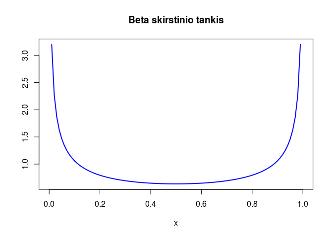

```r
curve(dbeta(x, 0.5, 0.5), main="Beta skirstinio tankis", ylab="", lwd=2, col=4)
```

Iš tiesų, šio skirstinio forma labai stipriai skiriai nuo normaliojo skirstinio formos. CTR teigia, kad nepaisant skirstionio, atsitiktinių dydžių skirstinys vis tiek turėtų supanašėti į normalųjį. Iš pradžių, pasižiūrėkime, kaip kinta vidurkio skirstinys, kai *n* = 1, 2, 3, 4. Tam panaudosime Monte-Carlo(MC) modeliavimą.

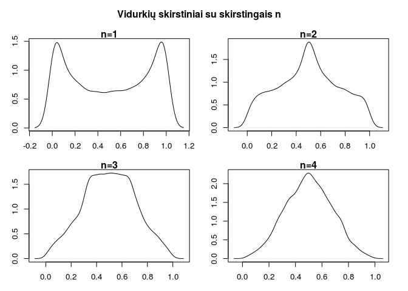

```r
meanMC <- function(n) mean(rbeta(n, 0.5, 0.5))
op <- par(mfrow = c(2, 2), mar=c(3,3,1,1), oma=c(0,0,3,1))
sim = replicate(10000, meanMC(1))
plot(density(sim), main="n=1", xlab="x", ylab="Tankis")
sim = replicate(10000, meanMC(2))
plot(density(sim), main="n=2", xlab="x", ylab="Tankis")
sim = replicate(10000, meanMC(3))
plot(density(sim), main="n=3", xlab="x", ylab="Tankis")
sim = replicate(10000, meanMC(4))
plot(density(sim), main="n=4", xlab="x", ylab="Tankis")
mtext("Vidurkių skirstiniai su skirstingais n", side=3, line=1,
      outer=TRUE, cex=1, font=2)
par(op)
```

Galime pastebėti, kad nes su net su nedideliais *n* vidurkis daug labiau primena normalųjį skirstinį, nei pradinį Beta skirstinį. Pasižiųrėkime, kaip atdoro vidurkio skirstinys, kai *n* = 100. Taip pat palyginkime tai su normaliuoju skirstiniu.

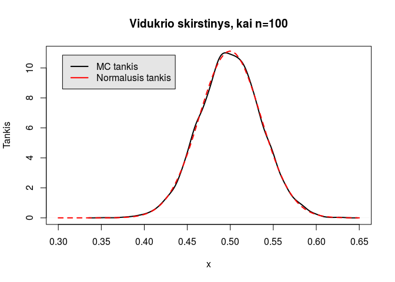

```r
sim = replicate(10000, meanMC(100))
plot(density(sim), main="Vidukrio skirstinys, kai n=100", xlab="x", ylab="Tankis",
     lwd=2, xlim=c(0.3, 0.65))
curve(dnorm(x, mean=mean(sim), sd=sd(sim)), add=TRUE, col=2, lwd=2, lty=2 )
legend("topleft", c("MC tankis", "Normalusis tankis"),
       lwd=2, col = 1:2,
       inset = .05, bg = "gray90")
```

Kaip matome, dabar skirstinių panašumas tampa labai ryškus – tiksliai taip, kad ir numato CRT.

Tai tik maža iliustracija demonstruojanti šią svarbią savybę. Tikiuosi jums patiko ir kažką naudingo sužinojote. Jei turite įpūdžių ar pastabū - prašau prašykite komentarą.